# TS_HW8_Liang_Gong

2025-02-28

# 12.3 Experiment with using NNETAR() on your retail data and other data we have considered in previous chapters.

You may want to compare its model performance against the traditional models we learned in the previous chapters and provide insights.

To get started with selecting your dataset, please use aus_retail in your R code.

You can sample your dataset from aus_retail, such as: myseries <- aus_retail |> filter( `Series ID` == sample(aus_retail$`Series ID`, 1), year(Month) < 2018 )

```r
library(ggplot2)
library(fpp3)
library(forecast)
library(patchwork)
library(fable)
library(fabletools)
library(tsibble)
library(dplyr)
library(tidyverse)
library(feasts)
library(lubridate)
library(fable)
library(fabletools)
library(lubridate)
library(broom)
library(glue)
library(tsibbledata)
library(zoo)
library(seasonal)
class(aus_retail)
```

```
## [1] "tbl_ts"     "tbl_df"     "tbl"        "data.frame"
```

```r
View(aus_retail)
```

```r
myseries <- aus_retail %>%
  filter(`Series ID` == "A3349744F", year(Month) < 2018)
```

```r
View(myseries)
```

```r
aus_retail_A3349744F <- myseries %>%
  select(Month, State, Turnover) %>%
  mutate(Month = yearmonth(Month)) %>%
  as_tsibble(index = Month)
```

# Look at the overall timeseries trend for Turnover

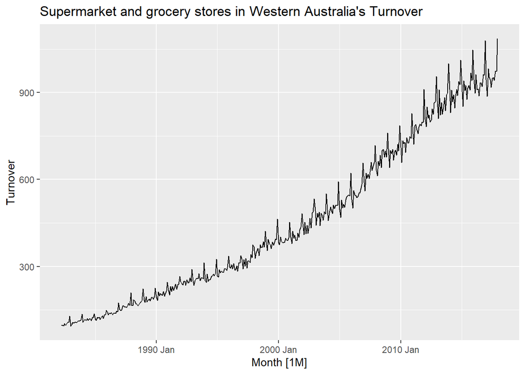

```r
autoplot(aus_retail_A3349744F, Turnover)+
  labs(y = "Turnover", title = "Supermarket and grocery stores in Western Australia's Turnover")
```

# NNETAR (Neural Network Time Series Autoregression)

A forecasting model in R that uses a feedforward neural network to model time series data. It is implemented in the forecast package and works like an autoregressive model, using past values as inputs.

```r
# The **square root transformation** is used to **stabilize variance** and **reduce the impact of large values** in the "Turnover" variable. This helps the **NNETAR** model learn patterns more effectively, especially if the data exhibits **heteroscedasticity** (changing variance over time). 🚀

nn_base <- aus_retail_A3349744F %>%
  filter(Month < max(Month)-36) %>%
  model(nn = NNETAR(sqrt(Turnover)))
```

```r
forecast_nn_base <- nn_base %>%
  forecast(h = 36)

print(forecast_nn_base)
```

```
## # A fable: 36 x 5 [1M]
## # Key:     State, .model [1]
##    State             .model    Month     Turnover .mean
##    <chr>             <chr>     <mth>       <dist> <dbl>
##  1 Western Australia nn     2014 Dec sample[5000] 1008.
##  2 Western Australia nn     2015 Jan sample[5000]  947.
##  3 Western Australia nn     2015 Feb sample[5000]  888.
##  4 Western Australia nn     2015 Mar sample[5000]  940.
##  5 Western Australia nn     2015 Apr sample[5000]  907.
##  6 Western Australia nn     2015 May sample[5000]  929.
##  7 Western Australia nn     2015 Jun sample[5000]  892.
##  8 Western Australia nn     2015 Jul sample[5000]  923.
##  9 Western Australia nn     2015 Aug sample[5000]  939.
## 10 Western Australia nn     2015 Sep sample[5000]  927.
## # ℹ 26 more rows
```

```r
View(forecast_nn_base)
```

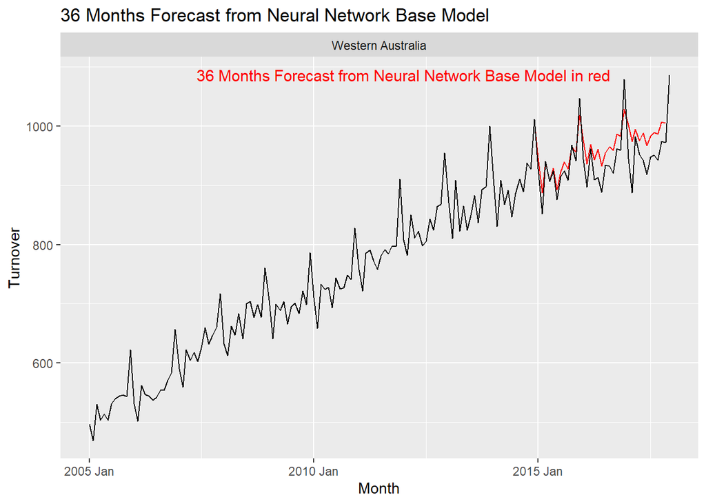

```r
forecast_nn_base %>%
  autoplot(aus_retail_A3349744F %>%
             filter(year(Month) >= 2005), level = NULL, color = "red") +
  labs(y = "Turnover", title = "36 Months Forecast from Neural Network Base Model") +
  facet_wrap(vars(State), scales = "free_y") +
  annotate("text", x = as.Date("2012-01-01"), y = max(aus_retail_A3349744F$Turnover),
           label = "36 Months Forecast from Neural Network Base Model in red", color = "red", size = 4)
```

# Analyze the residuals of the NNETAR model:

Some patterns in residuals → Possible missing information in the model.

ACF suggests some correlation in lags → The model may need additional lags.

Histogram looks roughly normal but may have outliers.

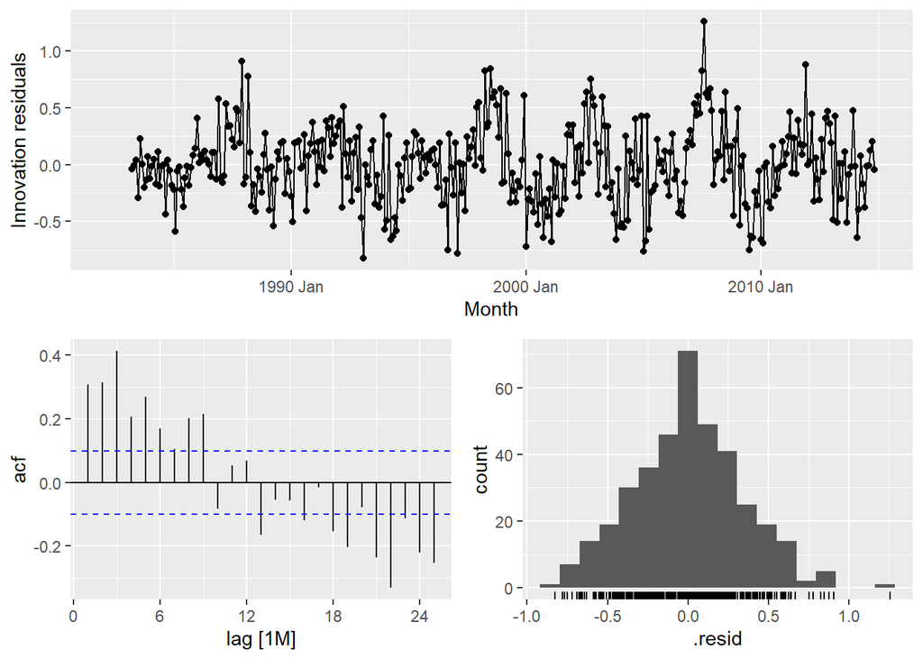

```r
nn_base |> select(nn) |> gg_tsresiduals()
```

# Check the model accuracy

```r
forecast_nn_base %>%
  accuracy(aus_retail_A3349744F, measures = list(rmsse = RMSSE, mase = MASE)) %>%
  group_by(.model) %>%
  summarise(rmsse = mean(rmsse), mase = mean(mase))
```

```
## # A tibble: 1 × 3
##   .model rmsse  mase
##   <chr>  <dbl> <dbl>
## 1 nn      1.08  1.11
```

# ETS Model

```r
ets_base <- aus_retail_A3349744F %>%
  filter(Month < max(Month)-36) %>%
  model(ets = ETS(sqrt(Turnover)))

forecast_ets_base <-
  ets_base %>%
  forecast(h = 36)

print(forecast_ets_base)
```

```
## # A fable: 36 x 5 [1M]
## # Key:     State, .model [1]
##    State             .model    Month        Turnover .mean
##    <chr>             <chr>     <mth>          <dist> <dbl>
##  1 Western Australia ets    2014 Dec t(N(32, 0.076)) 1017.
##  2 Western Australia ets    2015 Jan t(N(30, 0.083))  926.
##  3 Western Australia ets    2015 Feb  t(N(30, 0.09))  873.
##  4 Western Australia ets    2015 Mar t(N(31, 0.096))  950.
##  5 Western Australia ets    2015 Apr   t(N(30, 0.1))  916.
##  6 Western Australia ets    2015 May  t(N(31, 0.11))  934.
##  7 Western Australia ets    2015 Jun  t(N(30, 0.12))  901.
##  8 Western Australia ets    2015 Jul  t(N(31, 0.12))  935.
##  9 Western Australia ets    2015 Aug  t(N(31, 0.13))  954.
## 10 Western Australia ets    2015 Sep  t(N(31, 0.14))  932.
## # ℹ 26 more rows
```

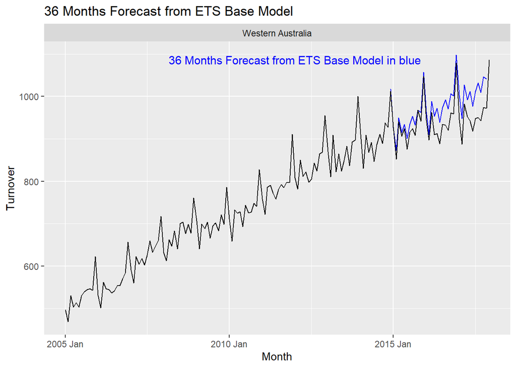

```r
forecast_ets_base %>%
  autoplot(aus_retail_A3349744F %>%
             filter(year(Month) >= 2005), level = NULL, color = "blue") +
  labs(y = "Turnover", title = "36 Months Forecast from ETS Base Model") +
  facet_wrap(vars(State), scales = "free_y") +
  annotate("text", x = as.Date("2012-01-01"), y = max(aus_retail_A3349744F$Turnover),
           label = "36 Months Forecast from ETS Base Model in blue", color = "blue", size = 4)
```

```r
forecast_ets_base %>%
  accuracy(aus_retail_A3349744F, measures = list(rmsse = RMSSE, mase = MASE)) %>%
  group_by(.model) %>%
  summarise(rmsse = mean(rmsse), mase = mean(mase))
```

```
## # A tibble: 1 × 3
##   .model rmsse  mase
##   <chr>  <dbl> <dbl>
## 1 ets     1.38  1.45
```

# ARIMA Model

```r
arima_base <- aus_retail_A3349744F %>%
  filter(Month < max(Month)-36) %>%
  model(arima = ARIMA(sqrt(Turnover)))

forecast_arima_base <-
  arima_base %>%
  forecast(h = 36)

print(forecast_arima_base)
```

```
## # A fable: 36 x 5 [1M]
## # Key:     State, .model [1]
##    State             .model    Month        Turnover .mean
##    <chr>             <chr>     <mth>          <dist> <dbl>
##  1 Western Australia arima  2014 Dec t(N(32, 0.065)) 1033.
##  2 Western Australia arima  2015 Jan t(N(31, 0.069))  943.
##  3 Western Australia arima  2015 Feb t(N(30, 0.084))  881.
##  4 Western Australia arima  2015 Mar  t(N(31, 0.11))  957.
##  5 Western Australia arima  2015 Apr  t(N(30, 0.12))  927.
##  6 Western Australia arima  2015 May  t(N(31, 0.14))  942.
##  7 Western Australia arima  2015 Jun  t(N(30, 0.16))  907.
##  8 Western Australia arima  2015 Jul  t(N(31, 0.17))  941.
##  9 Western Australia arima  2015 Aug  t(N(31, 0.19))  960.
## 10 Western Australia arima  2015 Sep   t(N(31, 0.2))  943.
## # ℹ 26 more rows
```

[figure not shown]

```r
forecast_arima_base %>%
  autoplot(aus_retail_A3349744F %>%
             filter(year(Month) >= 2005), level = NULL, color = "orange") +
  labs(y = "Turnover", title = "36 Months Forecast from ARIMA Base Model") +
  facet_wrap(vars(State), scales = "free_y") +
  annotate("text", x = as.Date("2012-01-01"), y = max(aus_retail_A3349744F$Turnover),
           label = "36 Months Forecast from ARIMA Base Model in blue", color = "orange", size = 4)
```

```r
forecast_arima_base %>%
  accuracy(aus_retail_A3349744F, measures = list(rmsse = RMSSE, mase = MASE)) %>%
  group_by(.model) %>%
  summarise(rmsse = mean(rmsse), mase = mean(mase))
```

```
## # A tibble: 1 × 3
##   .model rmsse  mase
##   <chr>  <dbl> <dbl>
## 1 arima   1.99  2.18
```

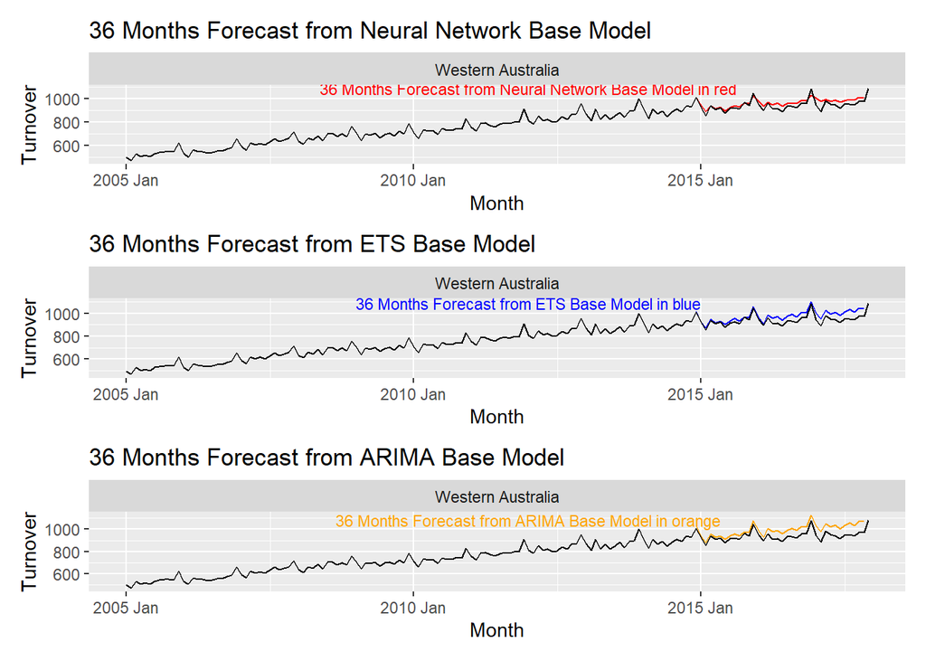

```r
library(patchwork)

# NNETAR Forecast
p1 <- forecast_nn_base %>%
  autoplot(aus_retail_A3349744F %>%
             filter(year(Month) >= 2005), level = NULL, color = "red") +
  labs(y = "Turnover", title = "36 Months Forecast from Neural Network Base Model") +
  facet_wrap(vars(State), scales = "free_y") +
  annotate("text", x = as.Date("2012-01-01"), y = max(aus_retail_A3349744F$Turnover),
           label = "36 Months Forecast from Neural Network Base Model in red", color = "red", size = 3)

# ETS Forecast
p2 <- forecast_ets_base %>%
  autoplot(aus_retail_A3349744F %>%
             filter(year(Month) >= 2005), level = NULL, color = "blue") +
  labs(y = "Turnover", title = "36 Months Forecast from ETS Base Model") +
  facet_wrap(vars(State), scales = "free_y") +
  annotate("text", x = as.Date("2012-01-01"), y = max(aus_retail_A3349744F$Turnover),
           label = "36 Months Forecast from ETS Base Model in blue", color = "blue", size = 3)

# ARIMA Forecast
p3 <- forecast_arima_base %>%
  autoplot(aus_retail_A3349744F %>%
             filter(year(Month) >= 2005), level = NULL, color = "orange") +
  labs(y = "Turnover", title = "36 Months Forecast from ARIMA Base Model") +
  facet_wrap(vars(State), scales = "free_y") +
  annotate("text", x = as.Date("2012-01-01"), y = max(aus_retail_A3349744F$Turnover),
           label = "36 Months Forecast from ARIMA Base Model in orange", color = "orange", size = 3)

# Combine plots using patchwork
combined_plot <- (p1 / p2 / p3) + plot_layout(heights = c(6, 6, 6))

options(repr.plot.height = 20)

# Display the combined plot
combined_plot
```

# Models Evaluation

### **Summary of the Model Performance Results**

The table presents the performance comparison of three different time series forecasting models: **Neural Network (NNETAR), Exponential Smoothing (ETS), and ARIMA**. The metrics used for evaluation are:

1. **RMSE-based Scale-Free Error (RMSSE)** – Measures the root mean squared scaled error. Lower values indicate better model performance.
2. **Mean Absolute Scaled Error (MASE)** – Measures the accuracy relative to a naive benchmark. Lower values suggest a better model.

### **Conclusion:**

- The **Neural Network (NNETAR) model** is the **best choice** for forecasting in this case, as it has the lowest errors.
- The **ETS model** is a reasonable alternative but is outperformed by the neural network.
- The **ARIMA model struggles the most**, likely due to the complex nature of the time series data, where nonlinear patterns may be better captured by NNETAR.

**Recommendation:** If model interpretability is important, ETS could be considered. However, if the priority is accuracy, the **Neural Network model should be preferred** for future forecasts.

```r
aus_combined_model_results <- bind_rows(

  forecast_nn_base %>%
    accuracy(aus_retail_A3349744F, measures = list(rmsse = RMSSE, mase = MASE)) %>%
    group_by(.model) %>%
    summarise(rmsse = mean(rmsse), mase = mean(mase)) %>%
    mutate(method = "Neural Network"),

  forecast_ets_base %>%
    accuracy(aus_retail_A3349744F, measures = list(rmsse = RMSSE, mase = MASE)) %>%
    group_by(.model) %>%
    summarise(rmsse = mean(rmsse), mase = mean(mase)) %>%
    mutate(method = "ETS"),

  forecast_arima_base %>%
    accuracy(aus_retail_A3349744F, measures = list(rmsse = RMSSE, mase = MASE)) %>%
    group_by(.model) %>%
    summarise(rmsse = mean(rmsse), mase = mean(mase)) %>%
    mutate(method = "ARIMA"),
)

print(aus_combined_model_results)
```

```
## # A tibble: 3 × 4
##   .model rmsse  mase method
##   <chr>  <dbl> <dbl> <chr>
## 1 nn      1.08  1.11 Neural Network
## 2 ets     1.38  1.45 ETS
## 3 arima   1.99  2.18 ARIMA
```